# Analise

### Atividade - Analise simples de dados

#### Bibliotecas e Leitura da base:

```python
import pandas as pd
import numpy as np
import matplotlib.pyplot as plt
import seaborn as sns
```

```python
df = pd.read_csv("tabela1.csv", sep=';', index_col = [0])
df
```

| Id | Turma | Sexo | Idade | Alt | Peso | Filhos | Fuma | Toler | Exerc | Cine | OpCine | TV | OpTV |
| --- | --- | --- | --- | --- | --- | --- | --- | --- | --- | --- | --- | --- | --- |
| 1 | A | F | 17 | 1.60 | 60.5 | 2 | NAO | P | 0 | 1 | B | 16 | R |
| 2 | A | F | 18 | 1.69 | 55.0 | 1 | NAO | M | 0 | 1 | B | 7 | R |
| 3 | A | M | 18 | 1.85 | 72.8 | 2 | NAO | P | 5 | 2 | M | 15 | R |
| 4 | A | M | 25 | 1.85 | 80.9 | 2 | NAO | P | 5 | 2 | B | 20 | R |
| 5 | A | F | 19 | 1.58 | 55.0 | 1 | NAO | M | 2 | 2 | B | 5 | R |
| 6 | A | M | 19 | 1.76 | 60.0 | 3 | NAO | M | 2 | 1 | B | 2 | R |
| 7 | A | F | 20 | 1.60 | 58.0 | 1 | NAO | P | 3 | 1 | B | 7 | R |
| 8 | A | F | 18 | 1.64 | 47.0 | 1 | SIM | I | 2 | 2 | M | 10 | R |
| 9 | A | F | 18 | 1.62 | 57.8 | 3 | NAO | M | 3 | 3 | M | 12 | R |
| 10 | A | F | 17 | 1.64 | 58.0 | 2 | NAO | M | 2 | 2 | M | 10 | R |
| 11 | A | F | 18 | 1.72 | 70.0 | 1 | SIM | I | 10 | 2 | B | 8 | N |
| 12 | A | F | 18 | 1.66 | 54.0 | 3 | NAO | M | 0 | 2 | B | 0 | R |
| 13 | A | F | 21 | 1.70 | 58.0 | 2 | NAO | M | 6 | 1 | M | 30 | R |
| 14 | A | M | 19 | 1.78 | 68.5 | 1 | SIM | I | 5 | 1 | M | 2 | N |
| 15 | A | F | 18 | 1.65 | 63.5 | 1 | NAO | I | 4 | 1 | B | 10 | R |
| 16 | A | F | 19 | 1.63 | 47.4 | 3 | NAO | P | 0 | 1 | B | 18 | R |
| 17 | A | F | 17 | 1.82 | 66.0 | 1 | NAO | P | 3 | 1 | B | 10 | N |
| 18 | A | M | 18 | 1.80 | 85.2 | 2 | NAO | P | 3 | 4 | B | 10 | R |
| 19 | A | NI | 20 | 1.60 | 54.5 | 1 | NAO | P | 3 | 2 | B | 5 | R |
| 20 | A | F | 18 | 1.68 | 52.5 | 3 | NAO | M | 7 | 2 | B | 14 | M |
| 21 | A | F | 21 | 1.70 | 60.0 | 2 | NAO | P | 8 | 2 | B | 5 | R |
| 22 | A | F | 18 | 1.65 | 58.5 | 1 | NAO | M | 0 | 3 | B | 5 | R |
| 23 | A | F | 18 | 1.57 | 49.2 | 1 | SIM | I | 5 | 4 | B | 10 | R |
| 24 | A | F | 20 | 1.55 | 48.0 | 1 | SIM | I | 0 | 1 | M | 28 | R |
| 25 | A | F | 20 | 1.69 | 51.6 | 2 | NAO | P | 8 | 5 | M | 4 | N |
| 26 | A | F | 19 | 1.54 | 57.0 | 2 | NAO | I | 6 | 2 | B | 5 | R |
| 27 | B | F | 23 | 1.62 | 63.0 | 2 | NAO | M | 8 | 2 | M | 5 | R |
| 28 | B | F | 18 | 1.62 | 52.0 | 1 | NAO | P | 1 | 1 | M | 10 | R |
| 29 | B | F | 18 | 1.57 | 49.0 | 2 | NAO | P | 3 | 1 | B | 12 | R |
| 30 | B | F | 25 | 1.65 | 59.0 | 4 | NAO | M | 1 | 2 | M | 2 | R |
| 31 | B | F | 18 | 1.61 | 52.0 | 1 | NAO | P | 2 | 2 | M | 6 | N |
| 32 | B | M | 17 | 1.71 | 73.0 | 1 | NAO | P | 1 | 1 | B | 20 | R |
| 33 | B | F | 17 | 1.65 | 56.0 | 3 | NAO | M | 2 | 1 | B | 14 | R |
| 34 | B | F | 17 | 1.67 | 58.0 | 1 | NAO | M | 4 | 2 | B | 10 | R |
| 35 | B | M | 18 | 1.73 | 87.0 | 1 | NAO | M | 7 | 1 | B | 25 | B |
| 36 | B | F | 18 | 1.60 | 47.0 | 1 | NAO | P | 5 | 1 | M | 14 | R |
| 37 | B | M | 17 | 1.70 | 95.0 | 1 | NAO | P | 10 | 2 | M | 12 | N |
| 38 | B | M | 21 | 1.85 | 84.0 | 1 | SIM | I | 6 | 4 | B | 10 | R |
| 39 | B | F | 18 | 1.70 | 60.0 | 1 | NAO | P | 5 | 2 | B | 12 | R |
| 40 | B | NI | 18 | 1.73 | 73.0 | 1 | NAO | M | 4 | 1 | B | 2 | R |
| 41 | B | F | 17 | 1.70 | 55.0 | 1 | NAO | I | 5 | 4 | B | 10 | B |
| 42 | B | F | 23 | 1.45 | 44.0 | 2 | NAO | M | 2 | 2 | B | 25 | R |
| 43 | B | M | 24 | 1.76 | 75.0 | 2 | NAO | I | 7 | 0 | M | 14 | N |
| 44 | B | F | 18 | 1.68 | 55.0 | 1 | NAO | P | 5 | 1 | B | 8 | R |
| 45 | B | F | 18 | 1.55 | 49.0 | 1 | NAO | M | 0 | 1 | M | 10 | R |
| 46 | B | F | 19 | 1.70 | 50.0 | 7 | NAO | M | 0 | 1 | B | 8 | R |
| 47 | B | F | 19 | 1.55 | 54.5 | 2 | NAO | M | 4 | 3 | B | 3 | R |
| 48 | B | F | 18 | 1.60 | 50.0 | 1 | NAO | P | 2 | 1 | B | 5 | R |
| 49 | B | M | 17 | 1.80 | 71.0 | 1 | NAO | P | 7 | 0 | M | 14 | R |
| 50 | B | M | 18 | 1.83 | 86.0 | 1 | NAO | P | 7 | 0 | M | 20 | B |

#### Analise 01 - Fumantes por genero

```python
quantidade_machos = len(df.loc[df['Sexo'] == 'M'])
quantidade_machos_fumantes = len(df.loc[(df['Sexo'] == 'M') & (df['Fuma'] == 'SIM')])
quantidade_femeas = len(df.loc[df['Sexo'] == 'F'])
quantidade_femeas_fumantes = len(df.loc[(df['Sexo'] == 'F') & (df['Fuma'] == 'SIM')])

print(f"Quantidade de homens: {quantidade_machos}")
print(f"Quantidade de homens fumantes: {quantidade_machos_fumantes}")
print(f"Porcentagem de homens fumantes: {(quantidade_machos_fumantes/quantidade_machos)*100:.2f}%\n")
print(f"Quantidade de mulheres: {quantidade_femeas}")
print(f"Quantidade de mulheres fumantes: {quantidade_femeas_fumantes}")
print(f"Porcentagem de mulheres fumantes: {(quantidade_femeas_fumantes/quantidade_femeas)*100:.2f}%")
```

```
Quantidade de homens: 12
Quantidade de homens fumantes: 2
Porcentagem de homens fumantes: 16.67%

Quantidade de mulheres: 36
Quantidade de mulheres fumantes: 4
Porcentagem de mulheres fumantes: 11.11%
```

Essa analise demosntra que embora existam mais mulheres que fumam, elas fazem parte de uma menor porcentagem do que os homens.

Podendo implicar que é mais fácil um homem fumar do que uma mulher.

#### Analise 02 - Verificar se a disposição do grupo influencia na decisão de fumar

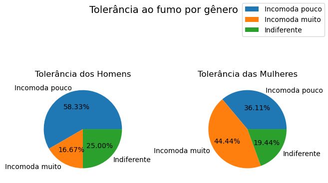

```python
df_machos = df.loc[df['Sexo'] == 'M']
macho_count = df_machos.value_counts("Toler", normalize=True)

df_femeas = df.loc[df['Sexo'] == 'F']
femea_count = df_femeas.value_counts("Toler", normalize=True)

indexes = ["Incomoda pouco", "Incomoda muito", "Indiferente"]
macho_tol = [macho_count['P'], macho_count['M'], macho_count['I']]
femea_tol = [femea_count['P'], femea_count['M'], femea_count['I']]

fig, axs = plt.subplots(1, 2, constrained_layout = True)
fig.suptitle("Tolerância ao fumo por gênero", fontsize=14)
axs[0].set_title("Tolerância dos Homens")
axs[0].pie(macho_tol, labels=indexes, autopct='%1.2f%%')

handles, labels = axs[0].get_legend_handles_labels()
fig.legend(handles, labels)

axs[1].set_title("Tolerância das Mulheres")
axs[1].pie(femea_tol, labels=indexes, autopct='%1.2f%%')
plt.show()
```

A partir do gráfico acima, podemos chegar à conclusão de que, em geral, os homens tendem a se importar menos com fumantes ao seu redor, enquanto as mulheres demonstram maior preocupação.

Dado que o ambiente influencia nas ações do indivíduo, as mulheres tendem a não fumar, já que a tolerância ao seu redor não o permitiria.

Por outro lado, os homens enfrentarão uma pressão menor e terão uma chance maior de se tornarem fumantes.

Essa conclusão está em consonância com a Análise 1 e pode revelar uma das implicações do resultado obtido.

#### Analise 03 - Correlação entre Peso e Altura

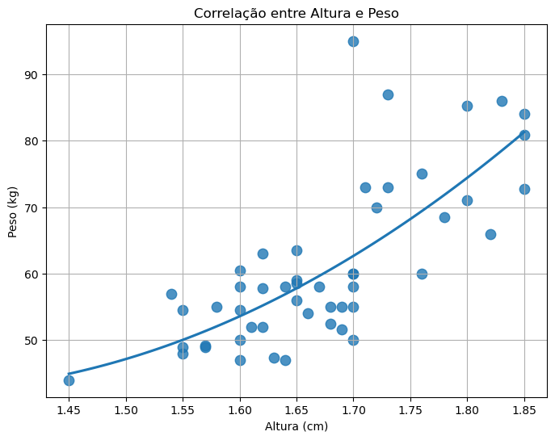

```python
plt.figure(figsize=(8, 6))
sns.regplot(x='Alt', y='Peso', data=df, ci=None, scatter_kws={"s": 80}, order=2)
plt.title('Correlação entre Altura e Peso')
plt.xlabel('Altura (cm)')
plt.ylabel('Peso (kg)')
plt.grid(True)
plt.show()
```

Observando o gráfico, fica evidente que, em geral, à medida que a altura de um indivíduo aumenta, seu peso também tende a aumentar. No entanto, é importante notar que o gráfico inclui uma linha que representa a tendência dos dados, calculado a partir de uma regressão.

Essa linha visa indicar que, apesar da tendência geral de aumento, os dados apresentam diversos desvios em relação à média. Mesmo que haja uma inclinação crescente, há variações consideráveis em torno dessa tendência normativa.

#### Analise 04 - Correlação entre Peso e Altura e Horas de Atividade Física

```python
imc = df['Peso'] / (df['Alt'] ** 2)
imc
```

```
Id
1     23.632812
2     19.257029
3     21.271001
4     23.637692
5     22.031726
6     19.369835
7     22.656250
8     17.474717
9     22.024082
10    21.564545
11    23.661439
12    19.596458
13    20.069204
14    21.619745
```

[output cut: 37 more lines]

[figure not shown]

```python
fig, axs = plt.subplots(1, 2, constrained_layout = True, figsize=(8,6))
fig.suptitle("Correlação entre Indice de Massa Corporal (IMC) e horas de exercício diárias", fontsize=14)

CORES = {
    'C': (0.8, 0.8, 0.8, 0.3),
    'Y': (1, 1, 0, 0.3),
    'G': (0, 1, 0, 0.3),
    'M': (1, 0, 1, 0.3),
}

axs[0].plot(imc, df["Exerc"], "o")
axs[0].axvspan(10, 18.5, color=CORES['C'], label='Abaixo do peso')
axs[0].axvspan(18.6, 24.9, color=CORES['Y'], label='Peso ideal')
axs[0].axvspan(25.0, 29.9, color=CORES['G'], label='Levemente acima do peso')
axs[0].axvspan(30.0, 34.9, color=CORES['M'], alpha=0.3, label='Obesidade grau I')
axs[0].set_xlim([15, 35])

lim = pd.cut(imc, bins=[0, 18.5, 25, 30, 35, 40, 45, 50]).value_counts()
lim = lim[lim!=0]

axs[1].pie(lim, autopct='%1.2f%%', startangle=90, pctdistance=1.25, colors=[CORES['C'], CORES['Y'], CORES['G'], CORES['M']])

handles, labels = axs[0].get_legend_handles_labels()
fig.legend(handles, labels, loc='lower right')

plt.show()
```

Em primeiro lugar, esta análise ilustra como é possível agrupar duas ou mais variáveis através de cálculos, criando uma variável composta que, em determinadas situações, pode ser mais significativa.

Além disso, a análise revela que uma quantidade reduzida de horas de exercício diário não necessariamente resulta em uma qualidade inferior do Índice de Massa Corporal (IMC), e a grande maioria está dentro dos padrões considerados aceitáveis.

#### Analise 05 - Tipo de midia preferida pelas turmas

```
{'Cinema Bom': (18, 14), 'Cinema Muito Bom': (8, 10), 'TV ruim': (21, 18), 'TV media': (1, 0), 'TV boa': (0, 3), 'TV ns': (4, 3)}
```

[figure not shown]

```python
dfA = df[df['Turma'] == 'A']
dfB = df[df['Turma'] == 'B']

turmas = ("Turma A", "Turma B")
preferencias = {
    'Cinema Bom': (dfA['OpCine'].value_counts().get('B', 0), dfB['OpCine'].value_counts().get('B', 0)),
    'Cinema Muito Bom': (dfA['OpCine'].value_counts().get('M', 0), dfB['OpCine'].value_counts().get('M', 0)),
    'TV ruim': (dfA['OpTV'].value_counts().get('R', 0), dfB['OpTV'].value_counts().get('R', 0)),
    'TV media': (dfA['OpTV'].value_counts().get('M', 0), dfB['OpTV'].value_counts().get('M', 0)),
    'TV boa': (dfA['OpTV'].value_counts().get('B', 0), dfB['OpTV'].value_counts().get('B', 0)),
    'TV ns': (dfA['OpTV'].value_counts().get('N', 0), dfB['OpTV'].value_counts().get('N', 0)),
}
print(preferencias)

x = np.arange(len(turmas))  # the label locations
width = 0.1  # the width of the bars
multiplier = 0

fig, ax = plt.subplots(constrained_layout = True, figsize=(8,6))

for attribute, measurement in preferencias.items():
    offset = width * multiplier
    rects = ax.bar(x + offset, measurement, width, label=attribute)
    ax.bar_label(rects, padding=1)
    multiplier += 1

# Add some text for labels, title and custom x-axis tick labels, etc.
ax.set_ylabel('Length (mm)')
ax.set_title('Penguin attributes by species')
ax.set_xticks(x + width, turmas)
ax.legend(loc='upper right')
ax.set_ylim(0, 25)

plt.show()
```

Este gráfico evidencia como os alunos percebem as mídias (TV e cinema).